# R Notebook

# Ejercicio 1

## Configuración

```r
#  Carga de librerías necesarias
library(tidyverse)
#  Carga de dataset
df <- read.csv("walmart.csv")
```

```r
# Ver estructura inicial
str(df)
```

```
## 'data.frame':    6435 obs. of  8 variables:
##  $ Store       : int  1 1 1 1 1 1 1 1 1 1 ...
##  $ Date        : chr  "05-02-2010" "12-02-2010" "19-02-2010" "26-02-2010" ...
##  $ Weekly_Sales: num  1643691 1641957 1611968 1409728 1554807 ...
##  $ Holiday_Flag: int  0 1 0 0 0 0 0 0 0 0 ...
##  $ Temperature : num  42.3 38.5 39.9 46.6 46.5 ...
##  $ Fuel_Price  : num  2.57 2.55 2.51 2.56 2.62 ...
##  $ CPI         : num  211 211 211 211 211 ...
##  $ Unemployment: num  8.11 8.11 8.11 8.11 8.11 ...
```

## EDA – Exploratory Data Analysis

## Gráficas de densidad

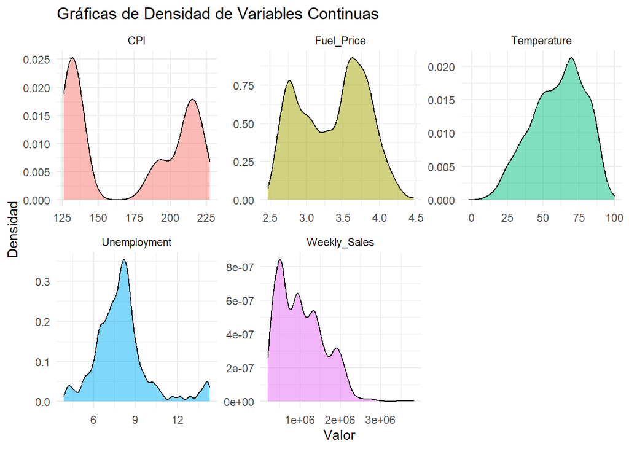

```r
# EDA 1.a: Gráficas de densidad para variables continuas
# Seleccionamos las columnas solicitadas y las pasamos a formato "largo" para graficar juntas
df_cont <- df %>%
  select(Weekly_Sales, Temperature, Fuel_Price, CPI, Unemployment) %>%
  pivot_longer(everything(), names_to = "variable", values_to = "valor")

# Crear el gráfico de densidad
ggplot(df_cont, aes(x = valor, fill = variable)) +
  geom_density(alpha = 0.5) +
  facet_wrap(~variable, scales = "free") +
  theme_minimal() +
  labs(title = "Gráficas de Densidad de Variables Continuas",
       x = "Valor",
       y = "Densidad") +
  theme(legend.position = "none")
```

#### Comentario: - **CPI y Fuel_Price**: Muestran un comportamiento claramente bimodal (dos picos pronunciados). - **Temperature y Unemployment**: Son las variables que más se aproximan a una forma normal, aunque Temperature muestra un ligero sesgo hacia la izquierda y Unemployment presenta cola menores en sus extremos. - **Weekly_Sales**: Tiene un fuerte sesgo a la derecha.

## Gráfica de barras para variables categoricas (Holiday_Flag y Store)

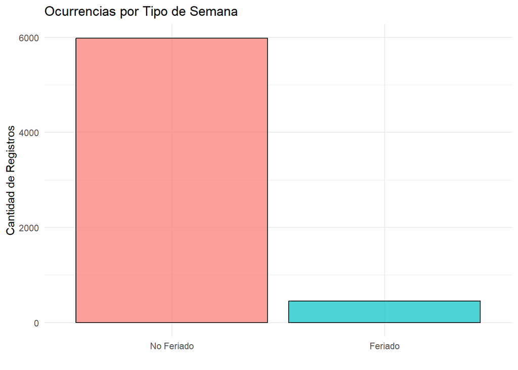

```r
# 1. Asegurarnos de que R interprete estas columnas como categóricas (Factores)
df_cat <- df %>%
  mutate(
    Holiday_Flag = factor(Holiday_Flag, labels = c("No Feriado", "Feriado")),
    Store = factor(Store)
  )

# Gráfica de barras para Holiday_Flag
p_bar_holiday <- ggplot(df_cat, aes(x = Holiday_Flag, fill = Holiday_Flag)) +
  geom_bar(color = "black", alpha = 0.7) +
  theme_minimal() +
  labs(title = "Ocurrencias por Tipo de Semana", x = "", y = "Cantidad de Registros") +
  theme(legend.position = "none")

# Gráfica de barras para Store
p_bar_store <- ggplot(df_cat, aes(x = Store)) +
  geom_bar(fill = "steelblue", color = "black", alpha = 0.7) +
  theme_minimal() +
  labs(title = "Ocurrencias por Tienda (Store)", x = "Número de Tienda", y = "Cantidad de Registros") +
  theme(axis.text.x = element_text(angle = 90, vjust = 0.5, size = 7)) # Rotamos etiquetas para que se lean bien

# Mostrar las barras
print(p_bar_holiday)
```

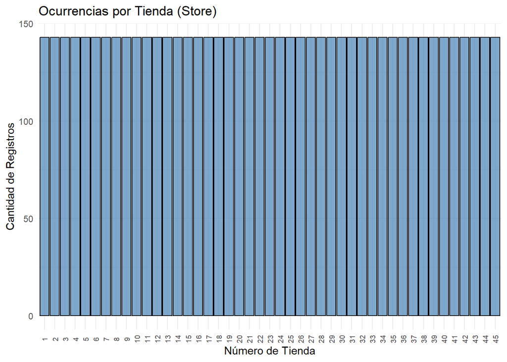

```r
print(p_bar_store)
```

## Boxplot vs Target (Weekky_sales)

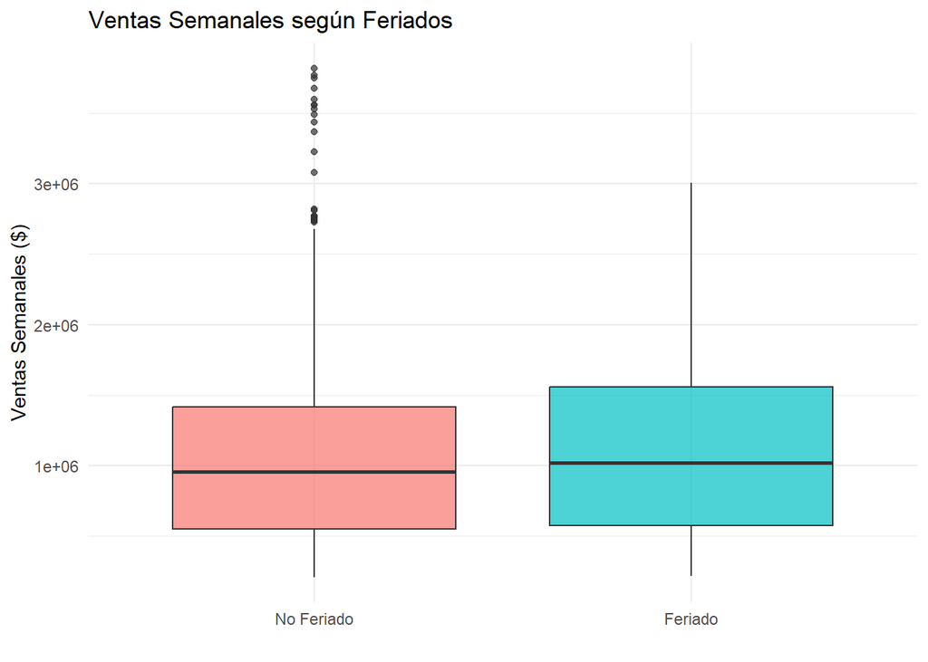

```r
# Boxplot: Holiday_Flag vs Weekly_Sales
p_box_holiday <- ggplot(df_cat, aes(x = Holiday_Flag, y = Weekly_Sales, fill = Holiday_Flag)) +
  geom_boxplot(alpha = 0.7) +
  theme_minimal() +
  labs(title = "Ventas Semanales según Feriados", x = "", y = "Ventas Semanales ($)") +
  theme(legend.position = "none")

# Boxplot: Store vs Weekly_Sales
p_box_store <- ggplot(df_cat, aes(x = Store, y = Weekly_Sales)) +
  geom_boxplot(fill = "orange", alpha = 0.6, outlier.size = 1) +
  theme_minimal() +
  labs(title = "Distribución de Ventas Semanales por Tienda", x = "Número de Tienda", y = "Ventas Semanales ($)") +
  theme(axis.text.x = element_text(angle = 90, vjust = 0.5, size = 7))

# Mostrar los boxplots
print(p_box_holiday)
```

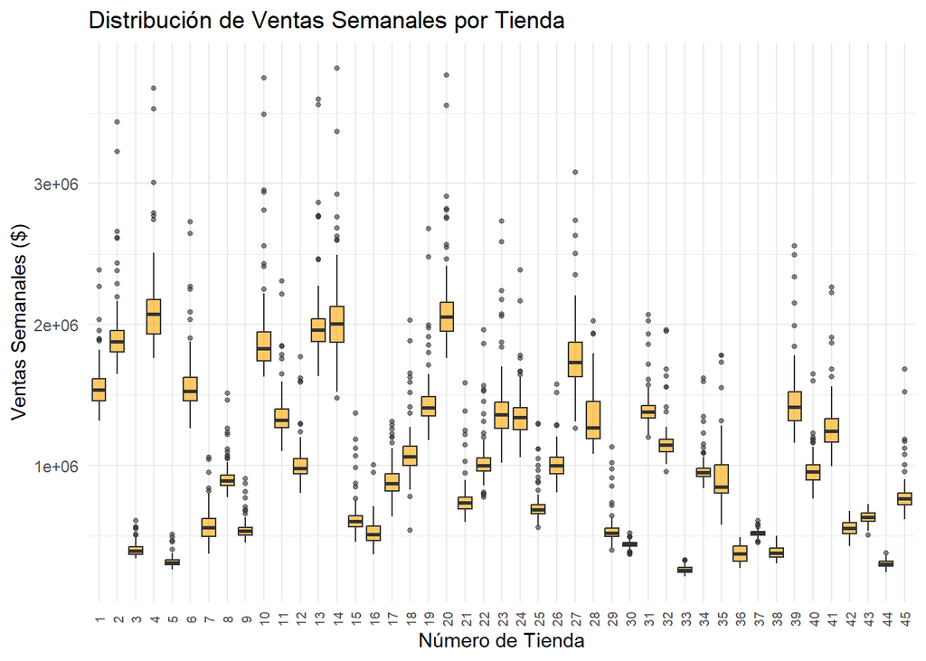

```r
print(p_box_store)
```

#### Comentario: - **Ventas Semanales según Feriados (Holiday_Flag)**: Al observar el primer gráfico, la mediana de las ventas durante las semanas con Feriado es ligeramente superior a la de las semanas sin feriado. El bigote superior de días feriados se extiende más hacia arriba, alcanzando un valor máximo cercano a los $3 millones. Las semanas sin feriado muestran valores atípicos en la parte superior.

- **Distribución de Ventas por Tienda (Store)**: Hay variación de ventas entre los distintos establecimientos. Existen tiendas con ventas altas, cuyas medianas rondan los $2 millones. Hay tiendas con ventas mucho menores, con medianas por debajo de los $500,000. Hay presencia de dispersión y outliers en la mayoría de las tiendas.

## Gráfica de serie temporal Weekly Sales - Date

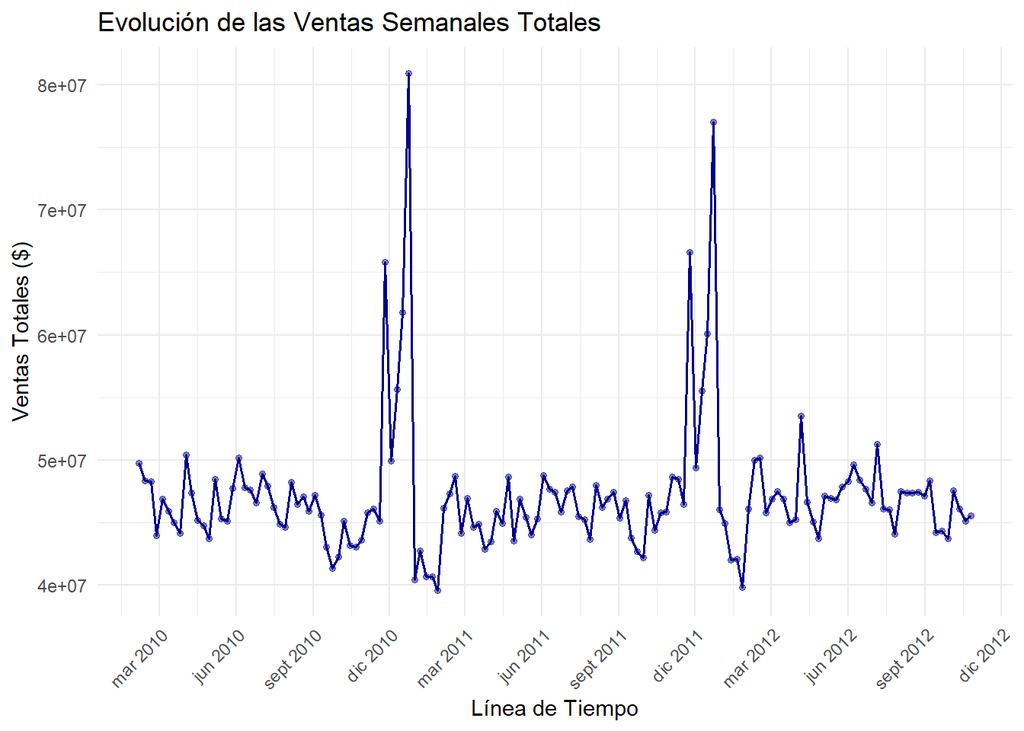

```r
# 1. Convertir la columna Date a formato de fecha real (Date)
# El formato del dataset viene como día-mes-año (dd-mm-yyyy)
df_time <- df %>%
  mutate(Date = as.Date(Date, format = "%d-%m-%Y"))

# 2. Agrupar las ventas totales de todas las tiendas por fecha

df_timeline <- df_time %>%
  group_by(Date) %>%
  summarise(Total_Weekly_Sales = sum(Weekly_Sales))

# 3. Crear la gráfica de serie temporal
ggplot(df_timeline, aes(x = Date, y = Total_Weekly_Sales)) +
  geom_line(color = "darkblue", size = 0.7) +
  geom_point(color = "darkblue", alpha = 0.5, size = 1.2) +
  scale_x_date(date_labels = "%b %Y", date_breaks = "3 months") +
  theme_minimal() +
  labs(
    title = "Evolución de las Ventas Semanales Totales",
    x = "Línea de Tiempo",
    y = "Ventas Totales ($)"
  ) +
  theme(axis.text.x = element_text(angle = 45, hjust = 1))
```

## Matriz de correlación para variables continuas

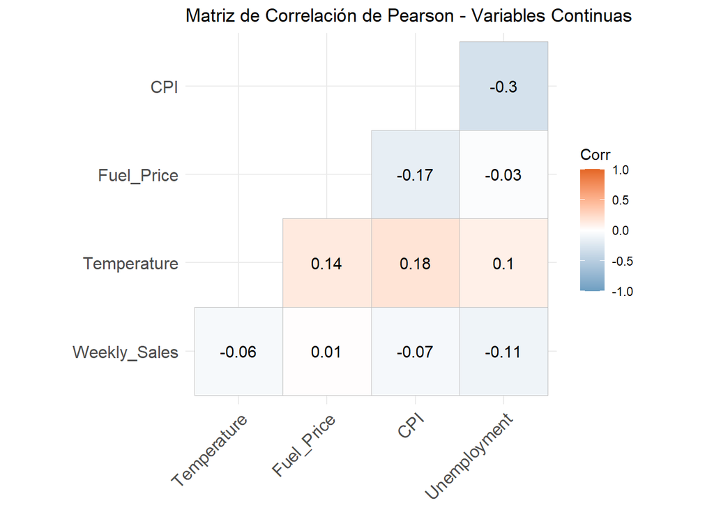

```r
# 1. Instalar y cargar ggcorrplot automáticamente si hace falta
if(!require(ggcorrplot)) install.packages("ggcorrplot")
library(ggcorrplot)

# 2. Seleccionar únicamente las variables continuas del dataset
df_continuas <- df %>%
  select(Weekly_Sales, Temperature, Fuel_Price, CPI, Unemployment)

# 3. Calcular la matriz de correlación de Pearson
matriz_corr <- cor(df_continuas, method = "pearson")

# 4. Graficar el mapa de calor (Heatmap)
ggcorrplot(
  matriz_corr,
  type = "lower",        # Muestra solo la mitad inferior para evitar duplicados repetidos
  lab = TRUE,            # Muestra los coeficientes numéricos dentro de los cuadros
  lab_size = 4,
  colors = c("#6D9EC1", "white", "#E46726"), # Azul para negativo, blanco neutro, naranja/rojo para positivo
  title = "Matriz de Correlación de Pearson - Variables Continuas",
  ggtheme = theme_minimal()
)
```

#### Comentario: Débil Relación Lineal Individual: Al observar la matriz de correlación, se observa que ninguna variable continua tiene una relación lineal fuerte por sí sola con la variable target (Weekly_Sales). Las correlaciones con Temperature (-0.06), Fuel_Price (0.01), CPI (-0.07) y Unemployment (-0.11) están sumamente cercanas a cero. Esto sugiere que un modelo de regresión lineal simple o basado puramente en estas variables de forma aislada tendrá un poder predictivo muy bajo.

Necesidad de Modelos Complejos y Regularización: serán indispensables técnicas que controlen la complejidad para evitar sobreajuste (como Ridge, LASSO y Elastic-Net).

## Convertir Date en variables numéricas y categóricas

```r
# 1. Asegurar la instalación y carga de lubridate
if(!require(lubridate)) install.packages("lubridate")
library(lubridate)

# 2. Ingeniería de características basadas en el tiempo (Corregido)
df_preparado <- df_time %>%
  mutate(
    Anio          = year(Date),                         # Extrae el año (ej. 2010)
    Mes           = month(Date),                        # Extrae el número de mes (1 al 12)
    Dia           = day(Date),                          # Extrae el día del mes (1 al 31)
    Dia_Semana    = wday(Date, week_start = 1),         # Día de la semana (5 = Viernes)
    Es_Fin_Semana = ifelse(Dia_Semana >= 6, "Si", "No") # Guardado directo como texto plano
  ) %>%
  # Eliminamos la columna de Date original como pide la guía
  select(-Date)

# 3. Ver el resultado en pantalla
df_preparado %>%
  select(Anio, Mes, Dia, Dia_Semana, Es_Fin_Semana) %>%
  head(5)
```

|  | Anio | Mes | Dia | Dia_Semana | Es_Fin_Semana |
| --- | --- | --- | --- | --- | --- |
| 1 | 2010 | 2 | 5 | 5 | No |
| 2 | 2010 | 2 | 12 | 5 | No |
| 3 | 2010 | 2 | 19 | 5 | No |
| 4 | 2010 | 2 | 26 | 5 | No |
| 5 | 2010 | 3 | 5 | 5 | No |

## Verificación de faltantes

```r
# Contar valores faltantes (NA) hay por cada columna
valores_faltantes <- colSums(is.na(df_preparado))

# Mostrar el conteo
print("Cantidad de datos faltantes por columna:")
```

```
## [1] "Cantidad de datos faltantes por columna:"
```

```r
print(valores_faltantes)
```

```
##         Store  Weekly_Sales  Holiday_Flag   Temperature    Fuel_Price
##             0             0             0             0             0
##           CPI  Unemployment          Anio           Mes           Dia
##             0             0             0             0             0
##    Dia_Semana Es_Fin_Semana
##             0             0
```

#### Comentario

Se realizó la verificación de valores nulos y el conteo arrojó un total de cero datos nulos en todas las columnas, por lo que no fue necesario aplicar ninguna estrategia de imputación.

## Partición de datos en Train y Test

```r
# Fijar una semilla para que la división sea reproducible
set.seed(123)

# Crear un índice aleatorio para seleccionar el 80% de las filas
# Usamos las filas totales de df_preparado
total_filas <- nrow(df_preparado)
indices_entrenamiento <- sample(1:total_filas, size = 0.8 * total_filas)

# Dividir el dataset utilizando el índice
train_data <- df_preparado[indices_entrenamiento, ]
test_data  <- df_preparado[-indices_entrenamiento, ]

# Verificar el tamaño de cada conjunto en pantalla
print(paste("Filas totales en Entrenamiento (Train):", nrow(train_data)))
```

```
## [1] "Filas totales en Entrenamiento (Train): 5148"
```

```r
print(paste("Filas totales en Testeo (Testing):", nrow(test_data)))
```

```
## [1] "Filas totales en Testeo (Testing): 1287"
```

```r
# Asegurar la instalación y carga de caret
if(!require(caret)) install.packages("caret")
library(caret)

# Definir el control de entrenamiento con Validación Cruzada de 10 pliegues
control_entrenamiento <- trainControl(
  method = "cv",          # cv = Cross-Validation
  number = 10,            # Número de pliegues (folds)
  verboseIter = FALSE     # Oculta el texto largo de cada iteración en la consola
)

# Confirmación visual en el reporte
print("Control de validación cruzada de 10 pliegues configurado exitosamente.")
```

```
## [1] "Control de validación cruzada de 10 pliegues configurado exitosamente."
```

## Implementación de modelos

### Regresión Lineal Múltiple

```r
# Limpiar los conjuntos quitando variables constantes (como Es_Fin_Semana)
# Mantenemos solo las variables que aportan variabilidad
train_data_clean <- train_data %>% select(-Es_Fin_Semana)
test_data_clean  <- test_data  %>% select(-Es_Fin_Semana)

# Entrenar nuevamente el modelo de Regresión Lineal Múltiple (lm)
modelo_lm <- train(
  Weekly_Sales ~ .,                  # Usa todas las variables restantes
  data = train_data_clean,           # Usamos el set limpio
  method = "lm",                     # lm = Linear Model
  trControl = control_entrenamiento  # Validación cruzada de 10 pliegues
)

# Mostrar el resumen de los resultados del entrenamiento
print("--- Resultados del Entrenamiento del Modelo Lineal ---")
```

```
## [1] "--- Resultados del Entrenamiento del Modelo Lineal ---"
```

```r
print(modelo_lm)
```

```
## Linear Regression
##
## 5148 samples
##   10 predictor
##
## No pre-processing
## Resampling: Cross-Validated (10 fold)
## Summary of sample sizes: 4634, 4632, 4634, 4633, 4634, 4634, ...
## Resampling results:
##
##   RMSE      Rsquared  MAE
##   521890.4  0.139139  431501.8
##
## Tuning parameter 'intercept' was held constant at a value of TRUE
```

```r
# Ver los coeficientes estadísticos
print("--- Resumen de Coeficientes Estadísticos ---")
```

```
## [1] "--- Resumen de Coeficientes Estadísticos ---"
```

```r
summary(modelo_lm$finalModel)
```

```
##
## Call:
## lm(formula = .outcome ~ ., data = dat)
##
## Residuals:
##      Min       1Q   Median       3Q      Max
## -1068938  -381766   -55395   378972  2573486
##
## Coefficients: (1 not defined because of singularities)
##                Estimate Std. Error t value Pr(>|t|)
## (Intercept)  61429682.7 33497497.8   1.834   0.0667 .
## Store          -14732.2      585.8 -25.148  < 2e-16 ***
## Holiday_Flag    20622.0    29407.5   0.701   0.4832
## Temperature     -2085.4      435.6  -4.787 1.74e-06 ***
## Fuel_Price      71902.8    28476.5   2.525   0.0116 *
## CPI             -2180.1      215.3 -10.125  < 2e-16 ***
## Unemployment   -23241.1     4381.3  -5.305 1.18e-07 ***
## Anio           -29685.7    16693.9  -1.778   0.0754 .
## Mes             15225.5     2457.4   6.196 6.25e-10 ***
## Dia              -399.1      830.6  -0.481   0.6309
## Dia_Semana           NA         NA      NA       NA
## ---
## Signif. codes:  0 '***' 0.001 '**' 0.01 '*' 0.05 '.' 0.1 ' ' 1
##
## Residual standard error: 521100 on 5138 degrees of freedom
## Multiple R-squared:  0.1423, Adjusted R-squared:  0.1408
## F-statistic:  94.7 on 9 and 5138 DF,  p-value: < 2.2e-16
```

### Ridge y LASSO

```r
# Asegurar que la librería de regularización esté lista
if(!require(glmnet)) install.packages("glmnet")
library(glmnet)

# --- ENTRENAR RIDGE (alpha = 0) ---
grid_ridge <- expand.grid(alpha = 0, lambda = seq(0.001, 100, length = 20))
modelo_ridge <- train(
  Weekly_Sales ~ ., data = train_data_clean, method = "glmnet",
  trControl = control_entrenamiento, tuneGrid = grid_ridge
)
print("--- MEJOR MODELO RIDGE ---")
```

```
## [1] "--- MEJOR MODELO RIDGE ---"
```

```r
print(modelo_ridge$results %>% filter(RMSE == min(RMSE)))
```

```
##    alpha     lambda     RMSE  Rsquared      MAE   RMSESD RsquaredSD    MAESD
## 1      0   0.001000 521612.5 0.1398664 431338.7 10664.85 0.02322261 8228.596
## 2      0   5.264105 521612.5 0.1398664 431338.7 10664.85 0.02322261 8228.596
## 3      0  10.527211 521612.5 0.1398664 431338.7 10664.85 0.02322261 8228.596
## 4      0  15.790316 521612.5 0.1398664 431338.7 10664.85 0.02322261 8228.596
## 5      0  21.053421 521612.5 0.1398664 431338.7 10664.85 0.02322261 8228.596
## 6      0  26.316526 521612.5 0.1398664 431338.7 10664.85 0.02322261 8228.596
## 7      0  31.579632 521612.5 0.1398664 431338.7 10664.85 0.02322261 8228.596
## 8      0  36.842737 521612.5 0.1398664 431338.7 10664.85 0.02322261 8228.596
## 9      0  42.105842 521612.5 0.1398664 431338.7 10664.85 0.02322261 8228.596
## 10     0  47.368947 521612.5 0.1398664 431338.7 10664.85 0.02322261 8228.596
## 11     0  52.632053 521612.5 0.1398664 431338.7 10664.85 0.02322261 8228.596
## 12     0  57.895158 521612.5 0.1398664 431338.7 10664.85 0.02322261 8228.596
## 13     0  63.158263 521612.5 0.1398664 431338.7 10664.85 0.02322261 8228.596
## 14     0  68.421368 521612.5 0.1398664 431338.7 10664.85 0.02322261 8228.596
## 15     0  73.684474 521612.5 0.1398664 431338.7 10664.85 0.02322261 8228.596
## 16     0  78.947579 521612.5 0.1398664 431338.7 10664.85 0.02322261 8228.596
## 17     0  84.210684 521612.5 0.1398664 431338.7 10664.85 0.02322261 8228.596
## 18     0  89.473789 521612.5 0.1398664 431338.7 10664.85 0.02322261 8228.596
## 19     0  94.736895 521612.5 0.1398664 431338.7 10664.85 0.02322261 8228.596
## 20     0 100.000000 521612.5 0.1398664 431338.7 10664.85 0.02322261 8228.596
```

```r
# --- ENTRENAR LASSO (alpha = 1) ---
grid_lasso <- expand.grid(alpha = 1, lambda = seq(0.001, 100, length = 20))
modelo_lasso <- train(
  Weekly_Sales ~ ., data = train_data_clean, method = "glmnet",
  trControl = control_entrenamiento, tuneGrid = grid_lasso
)
print("--- MEJOR MODELO LASSO ---")
```

```
## [1] "--- MEJOR MODELO LASSO ---"
```

```r
print(modelo_lasso$results %>% filter(RMSE == min(RMSE)))
```

```
##    alpha     lambda     RMSE  Rsquared      MAE   RMSESD RsquaredSD    MAESD
## 1      1   0.001000 521103.8 0.1404426 430930.5 17804.65 0.01766112 13147.63
## 2      1   5.264105 521103.8 0.1404426 430930.5 17804.65 0.01766112 13147.63
## 3      1  10.527211 521103.8 0.1404426 430930.5 17804.65 0.01766112 13147.63
## 4      1  15.790316 521103.8 0.1404426 430930.5 17804.65 0.01766112 13147.63
## 5      1  21.053421 521103.8 0.1404426 430930.5 17804.65 0.01766112 13147.63
## 6      1  26.316526 521103.8 0.1404426 430930.5 17804.65 0.01766112 13147.63
## 7      1  31.579632 521103.8 0.1404426 430930.5 17804.65 0.01766112 13147.63
## 8      1  36.842737 521103.8 0.1404426 430930.5 17804.65 0.01766112 13147.63
## 9      1  42.105842 521103.8 0.1404426 430930.5 17804.65 0.01766112 13147.63
## 10     1  47.368947 521103.8 0.1404426 430930.5 17804.65 0.01766112 13147.63
## 11     1  52.632053 521103.8 0.1404426 430930.5 17804.65 0.01766112 13147.63
## 12     1  57.895158 521103.8 0.1404426 430930.5 17804.65 0.01766112 13147.63
## 13     1  63.158263 521103.8 0.1404426 430930.5 17804.65 0.01766112 13147.63
## 14     1  68.421368 521103.8 0.1404426 430930.5 17804.65 0.01766112 13147.63
## 15     1  73.684474 521103.8 0.1404426 430930.5 17804.65 0.01766112 13147.63
## 16     1  78.947579 521103.8 0.1404426 430930.5 17804.65 0.01766112 13147.63
## 17     1  84.210684 521103.8 0.1404426 430930.5 17804.65 0.01766112 13147.63
## 18     1  89.473789 521103.8 0.1404426 430930.5 17804.65 0.01766112 13147.63
## 19     1  94.736895 521103.8 0.1404426 430930.5 17804.65 0.01766112 13147.63
## 20     1 100.000000 521103.8 0.1404426 430930.5 17804.65 0.01766112 13147.63
```

#### Comentario

Al aplicar los modelos de penalización, observamos un comportamiento plano donde las métricas de rendimiento (RMSE y R-squared) permanecen invariables frente a los cambios en el hiperparámetro lambda.

Las variables continuas actuales no tienen la estructura lineal necesaria para explicar el comportamiento de las ventas de forma aislada, replicando casi de manera idéntica los resultados del modelo lineal múltiple básico.

### Regresión Elastic-Net

```r
# 1.Probando alphas intermedios
grid_elastic <- expand.grid(
  alpha = seq(0.1, 0.9, by = 0.2),
  lambda = seq(0.001, 50, length = 10)
)

# Entrenar el modelo Elastic-Net
modelo_elastic <- train(
  Weekly_Sales ~ .,
  data = train_data_clean,
  method = "glmnet",
  trControl = control_entrenamiento,
  tuneGrid = grid_elastic
)

# Ver el resumen completo de las combinaciones
print("--- Resultados de Regresión Elastic-Net ---")
```

```
## [1] "--- Resultados de Regresión Elastic-Net ---"
```

```r
print(modelo_elastic$results)
```

```
##    alpha    lambda     RMSE  Rsquared      MAE   RMSESD RsquaredSD    MAESD
## 1    0.1  0.001000 521580.0 0.1401896 431142.1 10675.10 0.02383233 5716.368
## 2    0.1  5.556444 521580.0 0.1401896 431142.1 10675.10 0.02383233 5716.368
## 3    0.1 11.111889 521580.0 0.1401896 431142.1 10675.10 0.02383233 5716.368
## 4    0.1 16.667333 521580.0 0.1401896 431142.1 10675.10 0.02383233 5716.368
## 5    0.1 22.222778 521580.0 0.1401896 431142.1 10675.10 0.02383233 5716.368
## 6    0.1 27.778222 521580.0 0.1401896 431142.1 10675.10 0.02383233 5716.368
## 7    0.1 33.333667 521580.0 0.1401896 431142.1 10675.10 0.02383233 5716.368
## 8    0.1 38.889111 521580.0 0.1401896 431142.1 10675.10 0.02383233 5716.368
## 9    0.1 44.444556 521580.0 0.1401896 431142.1 10675.10 0.02383233 5716.368
## 10   0.1 50.000000 521580.0 0.1401896 431142.1 10675.10 0.02383233 5716.368
## 11   0.3  0.001000 521582.1 0.1401856 431132.7 10679.55 0.02382488 5724.119
## 12   0.3  5.556444 521582.1 0.1401856 431132.7 10679.55 0.02382488 5724.119
## 13   0.3 11.111889 521582.1 0.1401856 431132.7 10679.55 0.02382488 5724.119
## 14   0.3 16.667333 521582.1 0.1401856 431132.7 10679.55 0.02382488 5724.119
```

[output cut: 36 more lines]

### Modelo Stepwise (Forward Selection)

```r
# Asegurar la instalación de leaps
if(!require(leaps)) install.packages("leaps")
library(leaps)

# Definir cuántas variables máximas tiene tu dataset para la grilla (menú de pruebas)
max_predictores <- ncol(train_data_clean) - 1
grid_forward <- expand.grid(nvmax = 1:max_predictores)

# Entrenar el modelo usando Forward Selection (Método correcto: leapForward)
modelo_forward <- train(
  Weekly_Sales ~ .,
  data = train_data_clean,
  method = "leapForward",            # Nombre oficial en caret para selección hacia adelante
  trControl = control_entrenamiento, # Misma validación cruzada de 10 pliegues
  tuneGrid = grid_forward            # Evalúa el número óptimo de variables basadas en menor RMSE
)
#  Mostrar el rendimiento para cada número de variables
print("--- Evolución del RMSE por cantidad de variables ---")
```

```
## [1] "--- Evolución del RMSE por cantidad de variables ---"
```

```r
print(modelo_forward$results)
```

```
##    nvmax     RMSE  Rsquared      MAE   RMSESD RsquaredSD     MAESD
## 1      1 532712.4 0.1031092 438537.7 11046.65 0.02387615 10206.094
## 2      2 525944.4 0.1261296 433587.4 12845.83 0.03275384  9738.581
## 3      3 525613.1 0.1269736 432580.5 12238.44 0.03114070  8808.138
## 4      4 523446.7 0.1339677 431755.6 11429.25 0.02990072  8028.664
## 5      5 521352.6 0.1406749 430713.3 11840.73 0.02931710  8780.713
## 6      6 521282.8 0.1408882 430949.3 11761.07 0.02833088  8674.720
## 7      7 521161.8 0.1413148 430815.8 11749.33 0.02809375  8491.810
## 8      8 521344.4 0.1407126 430968.5 11763.33 0.02777509  8461.688
## 9      9 521310.5 0.1408224 430950.6 11744.86 0.02768944  8453.890
## 10    10 521310.5 0.1408224 430950.6 11744.86 0.02768944  8453.890
```

```r
# Ver cuántas variables seleccionó como la combinación ideal
print("--- Mejor Configuración Seleccionada ---")
```

```
## [1] "--- Mejor Configuración Seleccionada ---"
```

```r
print(modelo_forward$bestTune)
```

```
##   nvmax
## 7     7
```

## vi. Tabla comparativa

```r
# Asegurar que las librerías necesarias estén activas
library(dplyr)

# Función de evaluación sobre el conjunto de prueba
evaluar_modelo <- function(modelo, datos_test, nombre) {
  predicciones <- predict(modelo, newdata = datos_test)
  rmse_test <- RMSE(predicciones, datos_test$Weekly_Sales)
  r2_test   <- R2(predicciones, datos_test$Weekly_Sales)

  data.frame(
    Modelo = nombre,
    RMSE_Test = round(rmse_test, 2),
    Rsquared_Test = round(r2_test, 4)
  )
}

# Consolidar los 5 modelos entrenados
tabla_comparativa <- rbind(
  evaluar_modelo(modelo_lm, test_data_clean, "Regresión Lineal Múltiple"),
  evaluar_modelo(modelo_forward, test_data_clean, "Stepwise (Forward Selection)"),
  evaluar_modelo(modelo_ridge, test_data_clean, "Regresión Ridge"),
  evaluar_modelo(modelo_lasso, test_data_clean, "Regresión LASSO"),
  evaluar_modelo(modelo_elastic, test_data_clean, "Elastic-Net")
)

# Ordenar automáticamente del mejor al peor (Menor RMSE a Mayor RMSE)
tabla_ordenada <- tabla_comparativa %>% arrange(RMSE_Test)

# Desplegar la tabla final ordenada
print("--- TABLA COMPARATIVA ORDENADA (MEJOR A PEOR) ---")
```

```
## [1] "--- TABLA COMPARATIVA ORDENADA (MEJOR A PEOR) ---"
```

```r
print(tabla_ordenada)
```

```
##                         Modelo RMSE_Test Rsquared_Test
## 1    Regresión Lineal Múltiple  520754.0        0.1768
## 2              Regresión LASSO  520772.8        0.1768
## 3                  Elastic-Net  520789.5        0.1768
## 4              Regresión Ridge  521069.2        0.1770
## 5 Stepwise (Forward Selection)  521307.1        0.1748
```

#### Comentario

Estos valores demuestra que los factores macroeconómicos y climáticos de la empresa (Temperature, Fuel_Price, CPI, Unemployment) no interactúan de forma lineal con las ventas semanales. Los consumidores no alteran sus patrones de compra en Walmart de manera proporcional ante un cambio de temperatura o inflación. Por lo tanto, para elevar la precisión predictiva, es necesario explorar algoritmos basados en estructuras no lineales.

## vii. Entrenamiento con modelos con la configuración de hyperparámetros ganadora

```r
# =========================================================
#  EXTRACCIÓN DE MODELOS DEFINITIVOS GANADORES
# =========================================================

# Regresión Lineal Múltiple (Usa todas las variables)
modelo_final_lm <- modelo_lm$finalModel

# Stepwise Forward Selection (Fija la combinación ideal de 7 variables)
modelo_final_forward <- modelo_forward$finalModel

#  Regresión Ridge (Fija el mejor valor de lambda encontrado)
modelo_final_ridge <- modelo_ridge$finalModel

# Regresión LASSO (Fija el mejor valor de lambda encontrado)
modelo_final_lasso <- modelo_lasso$finalModel

# Elastic-Net (Fija la mejor combinación de alpha y lambda encontrada)
modelo_final_elastic <- modelo_elastic$finalModel

# Mensaje de confirmación
print("Paso vii completado con éxito. Los 5 modelos finales han sido extraídos.")
```

```
## [1] "Paso vii completado con éxito. Los 5 modelos finales han sido extraídos."
```

## viii. Calcular el rmse final en el dataset de testing

```r
# =========================================================
# PASO viii: CALCULAR EL RMSE FINAL EN EL DATASET DE TESTING
# =========================================================

# 1. Predicciones y RMSE para Regresión Lineal Múltiple
pred_lm <- predict(modelo_final_lm, newdata = test_data_clean)
rmse_final_lm <- RMSE(pred_lm, test_data_clean$Weekly_Sales)

# 2. Predicciones y RMSE para Stepwise (Forward Selection)
pred_forward <- predict(modelo_forward, newdata = test_data_clean)
rmse_final_forward <- RMSE(pred_forward, test_data_clean$Weekly_Sales)

# 3. Predicciones y RMSE para Regresión Ridge
pred_ridge <- predict(modelo_ridge, newdata = test_data_clean)
rmse_final_ridge <- RMSE(pred_ridge, test_data_clean$Weekly_Sales)

# 4. Predicciones y RMSE para Regresión LASSO
pred_lasso <- predict(modelo_lasso, newdata = test_data_clean)
rmse_final_lasso <- RMSE(pred_lasso, test_data_clean$Weekly_Sales)

# 5. Predicciones y RMSE para Elastic-Net
pred_elastic <- predict(modelo_elastic, newdata = test_data_clean)
rmse_final_elastic <- RMSE(pred_elastic, test_data_clean$Weekly_Sales)

# --- IMPRIMIR VALORES EN CONSOLA PARA VERIFICACIÓN ---
print("--- RMSE Finales (Conjunto de Testing) ---")
```

```
## [1] "--- RMSE Finales (Conjunto de Testing) ---"
```

```r
print(paste("LM Múltiple:", round(rmse_final_lm, 2)))
```

```
## [1] "LM Múltiple: 520753.99"
```

```r
print(paste("Stepwise Forward:", round(rmse_final_forward, 2)))
```

```
## [1] "Stepwise Forward: 521307.07"
```

```r
print(paste("Ridge:", round(rmse_final_ridge, 2)))
```

```
## [1] "Ridge: 521069.22"
```

```r
print(paste("LASSO:", round(rmse_final_lasso, 2)))
```

```
## [1] "LASSO: 520772.81"
```

```r
print(paste("Elastic-Net:", round(rmse_final_elastic, 2)))
```

```
## [1] "Elastic-Net: 520789.55"
```

## ix. Dataframe final

```r
# =========================================================
#  CREACIÓN DEL DATAFRAME DE REGISTRO
# =========================================================

# Definir los nombres y etiquetas cualitativas requeridas
nombres_modelos <- c(
  "Regresión Lineal Múltiple",
  "Stepwise (Forward Selection)",
  "Regresión Ridge",
  "Regresión LASSO",
  "Elastic-Net"
)

hyper_ganadores <- c(
  "No aplica (Modelo completo)",
  paste("nvmax =", modelo_forward$bestTune$nvmax),
  paste("alpha = 0, lambda =", round(modelo_ridge$bestTune$lambda, 4)),
  paste("alpha = 1, lambda =", round(modelo_lasso$bestTune$lambda, 4)),
  paste("alpha =", modelo_elastic$bestTune$alpha, ", lambda =", round(modelo_elastic$bestTune$lambda, 4))
)

#  Extraer de manera automatizada las variables incluidas (CORRECCIÓN LEAPS)
vars_lm      <- paste(names(coef(modelo_lm$finalModel))[-1], collapse = ", ")

# Agregamos id = 7 que es el nvmax ganador
vars_forward <- paste(names(coef(modelo_forward$finalModel, id = 7))[-1], collapse = ", ")

vars_ridge   <- paste(rownames(coef(modelo_ridge$finalModel, s = modelo_ridge$bestTune$lambda))[-1], collapse = ", ")
vars_lasso   <- paste(
  rownames(coef(modelo_lasso$finalModel, s = modelo_lasso$bestTune$lambda))[
    as.vector(coef(modelo_lasso$finalModel, s = modelo_lasso$bestTune$lambda)) != 0
  ][-1], collapse = ", "
)
vars_elastic <- paste(
  rownames(coef(modelo_elastic$finalModel, s = modelo_elastic$bestTune$lambda))[
    as.vector(coef(modelo_elastic$finalModel, s = modelo_elastic$bestTune$lambda)) != 0
  ][-1], collapse = ", "
)

# Consolidar el vector de RMSE finales calculados en el paso viii
rmse_registro <- c(
  rmse_final_lm,
  rmse_final_forward,
  rmse_final_ridge,
  rmse_final_lasso,
  rmse_final_elastic
)

#  Asignar los tags según rendimiento en Testing (image_0ee0ff)
tags_modelos <- c("Champion", "Deprecated", "Deprecated", "Challenger", "Challenger")

#  Armar el DataFrame Final
df_registro_modelos <- data.frame(
  Id = 1:5,
  Nombre_Modelo = nombres_modelos,
  Hyper_Parametros_Ganadores = hyper_ganadores,
  RMSE_Registro = round(rmse_registro, 2),
  Listado_Variables = c(vars_lm, vars_forward, vars_ridge, vars_lasso, vars_elastic),
  Tag_Modelo = tags_modelos,
  stringsAsFactors = FALSE
)

#  Desplegar el DataFrame
print("--- DATAFRAME DE REGISTRO FINAL DE EXPERIMENTOS ---")
```

```
## [1] "--- DATAFRAME DE REGISTRO FINAL DE EXPERIMENTOS ---"
```

```r
print(df_registro_modelos)
```

```
##   Id                Nombre_Modelo  Hyper_Parametros_Ganadores RMSE_Registro
## 1  1    Regresión Lineal Múltiple No aplica (Modelo completo)      520754.0
## 2  2 Stepwise (Forward Selection)                   nvmax = 7      521307.1
## 3  3              Regresión Ridge     alpha = 0, lambda = 100      521069.2
## 4  4              Regresión LASSO     alpha = 1, lambda = 100      520772.8
## 5  5                  Elastic-Net   alpha = 0.1 , lambda = 50      520789.5
##                                                                             Listado_Variables
## 1 Store, Holiday_Flag, Temperature, Fuel_Price, CPI, Unemployment, Anio, Mes, Dia, Dia_Semana
## 2                                Store, Temperature, Fuel_Price, CPI, Unemployment, Anio, Mes
## 3 Store, Holiday_Flag, Temperature, Fuel_Price, CPI, Unemployment, Anio, Mes, Dia, Dia_Semana
## 4             Store, Holiday_Flag, Temperature, Fuel_Price, CPI, Unemployment, Anio, Mes, Dia
## 5             Store, Holiday_Flag, Temperature, Fuel_Price, CPI, Unemployment, Anio, Mes, Dia
##   Tag_Modelo
## 1   Champion
## 2 Deprecated
## 3 Deprecated
## 4 Challenger
## 5 Challenger
```

#### Comentario

- **Modelo Campeón (Champion):** La **Regresión Lineal Múltiple** menor error del experimento (**RMSE: 520,754.0**).
- **Modelos Retadores (Challengers):** Tanto **Regresión LASSO** (RMSE: 520,772.8) como **Elastic-Net** (RMSE: 520,789.5) se consolidan como alternativas robustas. Su comportamiento casi idéntico al modelo lineal.
- **Modelos Descartados (Deprecated):** 1. **Regresión Ridge** (RMSE: 521,069.2), debido a que retiene todas las variables aplicando una penalización cuadrática uniforme que infla sutilmente el error residual en testeo. **Stepwise Forward Selection** (RMSE: 521,307.1),a pesar de aislar eficientemente 7 variables clave en el entrenamiento, pierde una ligera capacidad de generalización frente a datos completamente nuevos, quedando en la última posición.

**Conclusión Holística del Experimento Lineal:** La reducida dispersión entre los errores de los cinco modelos (una brecha máxima de apenas **$553.10 dólares** entre el peor y el mejor rendimiento sobre una escala de ventas millonaria) confirma un escenario generalizado de **sesgo alto (underfitting)**.

La demanda de los consumidores y las ventas semanales de las sucursales no interactúan de forma proporcional ni directa ante variaciones en el entorno Los patrones de consumo presentan curvaturas, estacionalidades complejas e interacciones cruzadas no lineales.

#### Generar archivo csv

```r
#  GENERAR ARCHIVO .CSV
write.csv(df_registro_modelos, file = "registro_resultados_modelos.csv", row.names = FALSE)
print("Archivo 'registro_resultados_modelos.csv' exportado exitosamente.")
```

```
## [1] "Archivo 'registro_resultados_modelos.csv' exportado exitosamente."
```

# Ejercicio #2: Investigación de Algoritmos No Lineales y Ensambles para Regresión

### 1. Árboles de Decisión para Regresiones

¿Cómo funciona el algoritmo? Divide datos recursivamente maximizando homogeneidad predictiva.

¿Para qué casos es bueno este algoritmo? Relaciones no lineales y datos con valores atípicos.

¿Para qué casos no es bueno este algoritmo? Datasets pequeños propensos a sobreajuste drástico.

¿Cuál es la complejidad computacional de este algoritmo? Entrenamiento rápido: O(n_features * n_samples * log(n_samples)).

¿Qué ventajas tiene este algoritmo sobre los demás? Alta interpretabilidad visual y nula preparación previa.

¿Qué desventajas tiene este algoritmo sobre los demás? Inestabilidad matemática ante cambios mínimos de datos.

Hiperparámetros clave (Sci-Kit Learn): max_depth: profundidad máxima; min_samples_split: muestras mínimas para dividir.

### 2. K-Nearest Neighbors (KNN) para Regresiones

¿Cómo funciona el algoritmo? Promedia los valores de los vecinos más cercanos.

¿Para qué casos es bueno este algoritmo? Estructuras de datos locales complejas y multimodales.

¿Para qué casos no es bueno este algoritmo? Grandes volúmenes de datos o dimensiones muy altas.

¿Cuál es la complejidad computacional de este algoritmo? Predicción costosa y lenta: O(n_samples * n_features).

¿Qué ventajas tiene este algoritmo sobre los demás? Algoritmo perezoso intuitivo sin suposiciones de distribución.

¿Qué desventajas tiene este algoritmo sobre los demás? Sensibilidad extrema a variables irrelevantes y escalas.

Hiperparámetros clave (Sci-Kit Learn): n_neighbors: número vecinos; weights: ponderación por distancia.

### 3. SVR – Support Vector Regression

¿Cómo funciona el algoritmo? Encuentra hiperplano ajustado dentro de margen aceptable.

¿Para qué casos es bueno este algoritmo? Espacios multidimensionales con relaciones no lineales complejas.

¿Para qué casos no es bueno este algoritmo? Muestras gigantescas por alto requerimiento de memoria.

¿Cuál es la complejidad computacional de este algoritmo? Escalabilidad cuadrática compleja: O(n_samples^2 * n_features).

¿Qué ventajas tiene este algoritmo sobre los demás? Robusto ante ruido y evita óptimos locales.

¿Qué desventajas tiene este algoritmo sobre los demás? Ajuste de hiperparámetros difícil y nula interpretabilidad.

Hiperparámetros clave (Sci-Kit Learn): C: regularización; kernel: tipo transformación; epsilon: margen.

### Ensambles para Regresiones

#### a. Random Forest

¿Cómo funciona el algoritmo? Promedia predicciones de múltiples árboles independientes aleatorios.

¿Para qué casos es bueno este algoritmo? Modelar interacciones complejas evitando el sobreajuste general.

¿Para qué casos no es bueno este algoritmo? Predicciones en tiempo real con memoria limitada.

¿Cuál es la complejidad computacional de este algoritmo? Entrenamiento paralelo: O(n_estimators * n_features * n_samples * log(n_samples)).

¿Qué ventajas tiene este algoritmo sobre los demás? Excelente precisión general y reduce varianza eficientemente.

¿Qué desventajas tiene este algoritmo sobre los demás? Caja negra costosa y lenta de procesar.

Hiperparámetros clave (Sci-Kit Learn): n_estimators: cantidad árboles; max_features: variables por división.

#### b. Gradient Boosting

¿Cómo funciona el algoritmo? Construye árboles secuenciales corrigiendo errores del anterior.

¿Para qué casos es bueno este algoritmo? Optimización precisa de métricas en datos estructurados.

¿Para qué casos no es bueno este algoritmo? Datos ruidosos propensos a sobreajuste muy rápido.

¿Cuál es la complejidad computacional de este algoritmo? Procesamiento puramente secuencial: O(n_estimators * n_samples * n_features).

¿Qué ventajas tiene este algoritmo sobre los demás? Poder predictivo sobresaliente minimizando sesgo del modelo.

¿Qué desventajas tiene este algoritmo sobre los demás? Entrenamiento lento debido a dependencia secuencial estricta.

Hiperparámetros clave (Sci-Kit Learn): learning_rate: escala aporte; n_estimators: iteraciones secuenciales.

#### c. XGBoost

¿Cómo funciona el algoritmo? Optimiza Gradient Boosting mediante regularización y paralelización.

¿Para qué casos es bueno este algoritmo? Competencias de datos y despliegues de alto rendimiento.

¿Para qué casos no es bueno este algoritmo? Datasets pequeños donde algoritmos simples bastan fácilmente.

¿Cuál es la complejidad computacional de este algoritmo? Estructura optimizada: O(n_estimators * n_features_efectivas * n_samples).

¿Qué ventajas tiene este algoritmo sobre los demás? Velocidad extrema, manejo de nulos y regularización.

¿Qué desventajas tiene este algoritmo sobre los demás? Arquitectura compleja con demasiados parámetros para ajustar.

Hiperparámetros clave (Sci-Kit Learn / API): max_depth: profundidad; subsample: porcentaje filas entrenamiento.

#### d. AdaBoost

¿Cómo funciona el algoritmo? Ajusta pesos dando prioridad a errores previos.

¿Para qué casos es bueno este algoritmo? Mejorar modelos débiles lineales o árboles pequeños.

¿Para qué casos no es bueno este algoritmo? Datos con alta presencia de ruido extremo.

¿Cuál es la complejidad computacional de este algoritmo? Dependencia lineal iterativa: O(n_estimators * n_samples * n_features).

¿Qué ventajas tiene este algoritmo sobre los demás? Fácil implementación sin requerir configuraciones complejas iniciales.

¿Qué desventajas tiene este algoritmo sobre los demás? Vulnerable a valores atípicos que desvían pesos.

### Hiperparámetros clave (Sci-Kit Learn):

estimator: modelo base; learning_rate: tasa de aprendizaje.

### Referencias:

James, G., Witten, D., Hastie, T., & Tibshirani, R. (2013). An Introduction to Statistical Learning. Springer.

Pedregosa, F. et al. (2011). Scikit-learn: Machine Learning in Python. Journal of Machine Learning Research, 12, 2825-2830.

Chen, T., & Guestrin, C. (2016). XGBoost: A Scalable Tree Boosting System. ACM SIGKDD.